# Anàlisi del padró de Girona 2020

Pol Monsó Purtí

2022-10-19

Una preview d’aquest document ‘knitted’ es pot trobar [aquí](https://htmlpreview.github.io/?https://raw.githubusercontent.com/polmonso/bigdata/master/summary_padro_girona.html)

## Índex

Les tasques que resoldrem en aquest exercici són les següents:

- Create a script to download information related to the register of inhabitants during 2020, and save the table in a file called padro_2020.RData
- Summarise the variable study levels (nivell_estudis). What are the most common levels?
- Summarise the average age within district (districte).
- Summarise the proportion of population with superior level studies in each district.
  - Visualització en taula
  - Visualització en forma de barres
  - Visualització en forma de mapa

## Install dependencies

```r
require('tidyverse')
require('dplyr')
require('ggplot2')
require('treemapify')
require('rgdal')
require('sf')
require('RColorBrewer')
require('classInt')
require('maptools')



library(readr)
library(tidyverse)
library(dplyr)
library(ggplot2)
library(treemapify)
library(rgdal)
library(sf)
library(RColorBrewer)
library(classInt)
library(maptools)
```

## Create a script to download information related to the register of inhabitants during 2020, and save the table in a file called padro_2020.RData

```r
filename = "data/padro_2020.RData"
csv_filename = "data/padro_2020.csv"
if(!file.exists(filename)){
  csv_url = "https://terra.girona.cat/opendata/storage/f/2021-04-19T07%3A52%3A25.797Z/padro-2021.csv"
  data = read_csv2(csv_url, col_types = cols(districte = "c", seccio = "c"))
  save(data, file=filename)
  #write.csv2(data, filename)
} else {
  load(filename)
  #data = read_csv2(filename, col_types = cols(districte = "c", seccio = "c"))
}
```

```r
shapefile = 'data/girona_shp/Barris.shp'
if(!file.exists(shapefile)){
  destfile = "data/girona_shp.zip"
  girona_shp_zip = 'https://terra.girona.cat/opendata/storage/f/2021-06-28T10%3A49%3A46.540Z/seccions.zip'
  download.file(girona_shp_zip , destfile=destfile)
  unzip(destfile, exdir='data/girona_shp')
}
```

Malauradament els barris no coincideixen amb els districtes :(

Haurem de baixar-nos les seccions censals.

```r
shapefile = 'data/girona_seccions_shp/Seccions.shp'
if(!file.exists(shapefile)){
  destfile = "data/girona_seccions_shp.zip"
  girona_shp_zip = 'https://terra.girona.cat/opendata/storage/f/2021-06-28T10%3A49%3A46.540Z/seccions.zip'
  download.file(girona_shp_zip , destfile=destfile)
  unzip(destfile, exdir='data/girona_seccions_shp')
}
```

La shapefile per seccions és massa granularitzada: les seccions conformen els districtes. Quan fem el mapa les unirem.

## Summarise the variable study levels (nivell_estudis). What are the most common levels?

```r
arrange(summarize(group_by(data, nivell_estudis), popularitat = as.numeric(100*n()/count(data))), desc(popularitat))
```

```
## # A tibble: 15 × 2
##    nivell_estudis            popularitat
##    <chr>                           <dbl>
##  1 ESO, PRIMÀRIA O EQUIV.         22.3
##  2 NO APLICABLE MENOR 16          18.4
##  3 BATXILLER SUPERIOR, BUP        15.3
##  4 LLICENCIAT O GRAU UNIVER.      11.5
##  5 PRIMÀRIA INCOMPLETA            10.0
##  6 FP 2ON GRAU O SUPERIOR          4.57
##  7 FP 1ER GRAU O MITJÀ             3.99
##  8 DOCTORAT I POST-GRAU            3.61
##  9 DIPLOMAT ESCOLA UNIVERS.        3.53
## 10 BATXILLER,FPII O SUPERIOR       2.17
## 11 SENSE ESTUDIS                   1.74
## 12 ARQUITECTE,ENGINYER TÈCNI       0.916
## 13 ALTRES TÍTOLS DE GRAU MIG       0.875
## 14 NI LLEGIR NI ESCRIURE           0.571
## 15 TÍTOL SUP NO UNIVERSITARI       0.457
```

La majoria de la població no ha passat a estudis superiors. Per sort, el tant per cent de gent que no ha estat escolaritzada és força baix, tot i que segueix sent massa tenint en compte que l’educació secundària és obligatòria.

## Summarise the average age within district (districte).

```r
summarize(group_by(data, districte), edat_mitja = mean(as.integer(format(Sys.Date(), "%Y")) - data_naixement))
```

```
## # A tibble: 6 × 2
##   districte edat_mitja
##   <chr>          <dbl>
## 1 1               40.7
## 2 2               43.5
## 3 3               41.6
## 4 4               42.7
## 5 5               43.4
## 6 6               43.2
```

Com era d’esperar, l’edat mitja està força uniformament repartida entre els districtes. Tot i que potser podríem trobar una certa preferència a la perifèria a mida que augmenta l’edat.

Com que l’edat està força uniformament repartida, l’anàlisi del nivell d’estudis no es veurà gaire esbiaixat per la distribució d’edat.

## Summarise the proportion of population with superior level studies in each district.

Obtenim la llista d’estudis

```r
summarize(group_by(data, nivell_estudis))
```

```
## # A tibble: 15 × 1
##    nivell_estudis
##    <chr>
##  1 ALTRES TÍTOLS DE GRAU MIG
##  2 ARQUITECTE,ENGINYER TÈCNI
##  3 BATXILLER SUPERIOR, BUP
##  4 BATXILLER,FPII O SUPERIOR
##  5 DIPLOMAT ESCOLA UNIVERS.
##  6 DOCTORAT I POST-GRAU
##  7 ESO, PRIMÀRIA O EQUIV.
##  8 FP 1ER GRAU O MITJÀ
##  9 FP 2ON GRAU O SUPERIOR
## 10 LLICENCIAT O GRAU UNIVER.
## 11 NI LLEGIR NI ESCRIURE
## 12 NO APLICABLE MENOR 16
## 13 PRIMÀRIA INCOMPLETA
## 14 SENSE ESTUDIS
## 15 TÍTOL SUP NO UNIVERSITARI
```

Els estudis superiors són:

```r
estudis_superiors = c(
  'ALTRES TÍTOLS DE GRAU MIG',
  'ARQUITECTE,ENGINYERTÈCNI',
  'DIPLOMAT ESCOLA UNIVERS.',
  'DOCTORAT I POST-GRAU',
  'FP 1ER GRAU O MITJÀ',
  'FP 2ON GRAU O SUPERIOR',
  'LLICENCIAT O GRAU UNIVER.',
  'TÍTOL SUP NO UNIVERSITARI'
)

summarize(group_by(data, districte), superiors = 100*mean(nivell_estudis %in% estudis_superiors, rm.NA = TRUE))
```

```
## # A tibble: 6 × 2
##   districte superiors
##   <chr>         <dbl>
## 1 1              22.3
## 2 2              35.5
## 3 3              24.4
## 4 4              34.3
## 5 5              29.2
## 6 6              24.3
```

si volem treure els menors de 16

```r
data_adults = filter(data, nivell_estudis != 'NO APLICABLE MENOR 16')
dist_estudis = summarize(group_by(data_adults, districte), superiors = round(100*mean(nivell_estudis %in% estudis_superiors, rm.NA = TRUE), digits = 2))
dist_estudis
```

```
## # A tibble: 6 × 2
##   districte superiors
##   <chr>         <dbl>
## 1 1              28.4
## 2 2              43.2
## 3 3              29.9
## 4 4              39.1
## 5 5              35.8
## 6 6              29.7
```

*Visualització en forma de barres*

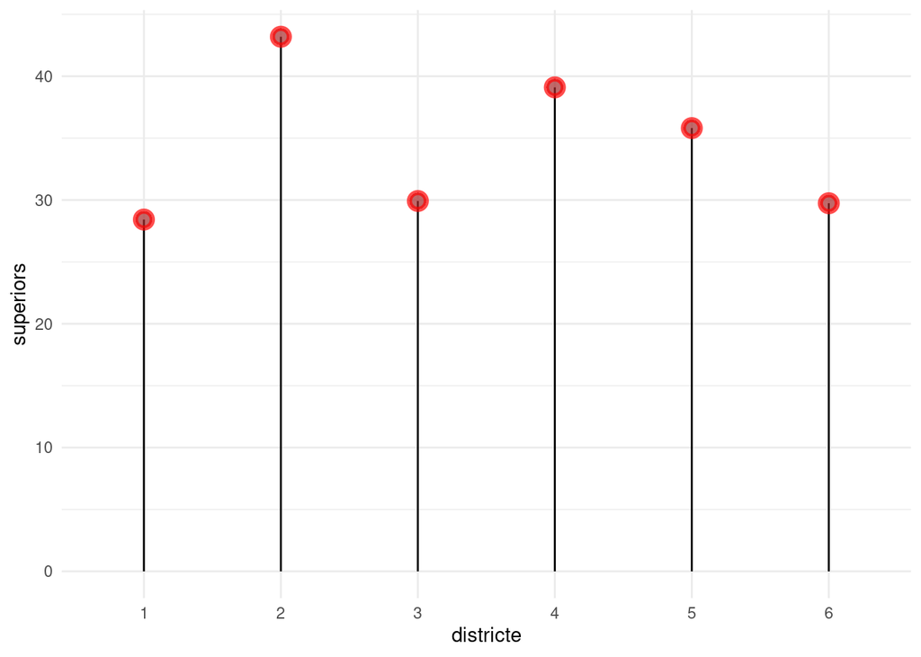

```r
ggplot(dist_estudis, aes(x=districte, y=superiors, labels=districte)) +
  geom_segment( aes(x=districte, xend=districte, y=0, yend=superiors)) +
  geom_point( size=3, color="red", fill=alpha("brown", 0.3), alpha=0.7, shape=21, stroke=2) +
  theme_minimal()
```

*Visualització en forma de mapa*

Carreguem el shapefile de les seccions censals i unim els polígons per districte.

```r
seccio_sf = st_read(shapefile)
## Reading layer `Seccions' from data source
##   `/home/pol/code/bigdata1/data/girona_seccions_shp/Seccions.shp'
##   using driver `ESRI Shapefile'
## Simple feature collection with 74 features and 11 fields
## Geometry type: POLYGON
## Dimension:     XY
## Bounding box:  xmin: 482002 ymin: 4643046 xmax: 491535.4 ymax: 4653103
## Projected CRS: ETRS89 / UTM zone 31N
districte_sf = summarise(group_by(seccio_sf, DISTRICTE))
```

Calculem la paleta de colors i ho dibuixem

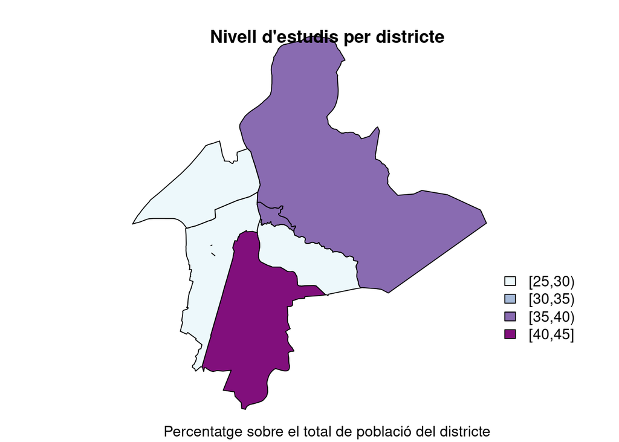

```r
nclr = 5 #nrow(dist_estudis)
plotclr = brewer.pal(nclr,"BuPu")
class = classIntervals(pull(dist_estudis), nclr, style="pretty")#,warnSmallN=FALSE)
#class = classIntervals(pull(dist_estudis), style="fixed",fixedBreaks=c(20,25,30,40,45,50))
colcode = findColours(class, plotclr)

title = "Nivell d'estudis per districte"
subtitle = "Percentatge sobre el total de població del districte"
plot(districte_sf['DISTRICTE'], col=colcode, main=NULL)
title(main=title, sub=subtitle)
legend("bottomright", legend=names(attr(colcode, "table")), #alternative paste0(as.character(sort(pull(dist_estudis))), " ", names(attr(colcode, "table"))),
       fill=attr(colcode, "palette"), cex=1.0, bty="n")
```

Podem observar una diferència notable entre els districtes 2, 4 i 5 en comparació als altres. Potser la presència de la zona universitària al districte 2 decanta la balança cap als estudis superiors.

En la visualització en forma de mapa podem observar que els districtes entre 35-40 % no són al voltant del districte universitari. Caldria buscar altres variables per a explicar les diferències entre districtes que queden fora de l’abast d’aquest exercici.